# real_covid

## 1. Introduction

The COVID-19 pandemic has challenged public health organizations globally to predict and understand key factors influencing the virus's transmission and outcomes. In response to this, I have developed a predictive modeling system for this project. The system aims to provide insights into the COVID-19 pandemic's progression, forecast future trends, and inform decisions regarding health resource allocation and policy-making.

## 2. Data Preparation

The data used for this analysis comes from Kaggle data source, primarily focusing on the global spread of COVID-19. The initial dataset includes features such as confirmed cases, deaths, recoveries, and active cases across countries/regions, along with temporal information.

## Data Import and Inspection

I began by importing the data and performing an initial inspection to understand its structure and identify any missing or erroneous values.

# Importing all the necessary Libraries

```python
import pandas as pd
import numpy as np
import matplotlib.pyplot as plt
import seaborn as sns
%matplotlib inline
```

```python
# Step 2: IMPORT AND PREPROCESSING DATA
data = pd.read_csv("C:\\Users\\hp\Documents\\covid_19_clean_complete.csv")
```

## 3. Exploratory Data Analysis (EDA)

Exploratory data analysis (EDA) helped us uncover key patterns in the data, identify relationships between variables, and prepare the data for modeling. We performed various visualizations and statistical checks.

## Missing Data and Descriptive Statistics

I checked for missing data and generated summary statistics to understand the distribution of key variables:

```python
#check the first 5 rows of the data
print(data.head())
print(data.columns)
```

```
  Province/State Country/Region       Lat       Long        Date  Confirmed  \
0            NaN    Afghanistan  33.93911  67.709953  2020-01-22          0
1            NaN        Albania  41.15330  20.168300  2020-01-22          0
2            NaN        Algeria  28.03390   1.659600  2020-01-22          0
3            NaN        Andorra  42.50630   1.521800  2020-01-22          0
4            NaN         Angola -11.20270  17.873900  2020-01-22          0

   Deaths  Recovered  Active             WHO Region
0       0          0       0  Eastern Mediterranean
1       0          0       0                 Europe
2       0          0       0                 Africa
3       0          0       0                 Europe
4       0          0       0                 Africa
Index(['Province/State', 'Country/Region', 'Lat', 'Long', 'Date', 'Confirmed',
       'Deaths', 'Recovered', 'Active', 'WHO Region'],
      dtype='object')
```

```python
#describe the data
print(data.describe())
```

```
                Lat          Long     Confirmed         Deaths     Recovered  \
count  49068.000000  49068.000000  4.906800e+04   49068.000000  4.906800e+04
mean      21.433730     23.528236  1.688490e+04     884.179160  7.915713e+03
std       24.950320     70.442740  1.273002e+05    6313.584411  5.480092e+04
min      -51.796300   -135.000000  0.000000e+00       0.000000  0.000000e+00
25%        7.873054    -15.310100  4.000000e+00       0.000000  0.000000e+00
50%       23.634500     21.745300  1.680000e+02       2.000000  2.900000e+01
75%       41.204380     80.771797  1.518250e+03      30.000000  6.660000e+02
max       71.706900    178.065000  4.290259e+06  148011.000000  1.846641e+06

             Active
count  4.906800e+04
mean   8.085012e+03
std    7.625890e+04
min   -1.400000e+01
25%    0.000000e+00
50%    2.600000e+01
75%    6.060000e+02
max    2.816444e+06
```

```python
#check for missing value
print(data.isnull().sum())
```

```
Province/State    34404
Country/Region        0
Lat                   0
Long                  0
Date                  0
Confirmed             0
Deaths                0
Recovered             0
Active                0
WHO Region            0
dtype: int64
```

## Handling Missing Data

The dataset contained missing values, especially in the *Province/State* column. We handled this by filling missing values with 'Unknown'.

```python
# Step 3: HANDLING MISSING VALUES
data['Province/State'].fillna('Unknown', inplace=True)
# Active Case = confirmed - deaths - recovered
data['Active'] = data['Confirmed'] - data[ 'Deaths'] - data['Recovered']
#Additionally, we created a new feature, *Active*, which calculates the active cases as the difference between confirmed cases, deaths, and recoveries:
```

```python
#I also ensured that the *Date* column was in proper datetime format for time-series analysis:
#Transform date column to datetime format

from datetime import datetime as dt

data['Date'] = pd.to_datetime(data['Date'])


data['Date'] = data['Date'].dt.normalize()
data['Date'] = data['Date'].dt.strftime('%Y-%m-%d')

a = data.Date.value_counts().sort_index()
print(f"the first date is: {a.index[0]}")
print(f"the last date is: {a.index[-1]}")

total_cases = data.loc[:, ['Date', 'Confirmed']].groupby('Date').sum().reset_index()
total_cases
```

```
the first date is: 2020-01-22
the last date is: 2020-07-27
```

|  | Date | Confirmed |
| --- | --- | --- |
| 0 | 2020-01-22 | 555 |
| 1 | 2020-01-23 | 654 |
| 2 | 2020-01-24 | 941 |
| 3 | 2020-01-25 | 1434 |
| 4 | 2020-01-26 | 2118 |
| ... | ... | ... |
| 183 | 2020-07-23 | 15510481 |
| 184 | 2020-07-24 | 15791645 |
| 185 | 2020-07-25 | 16047190 |
| 186 | 2020-07-26 | 16251796 |
| 187 | 2020-07-27 | 16480485 |

188 rows × 2 columns

```python
#Step 4: FEARTURE ENGINEERING

#load a new dataset with the new features
data_1=pd.read_csv("C:\\Users\\hp\\Documents\\worldometer_data.csv")

# Find the common columns
common_columns = set(data) & set(data_1)

# Print the common columns
print("Common columns:")
for column in common_columns:
    print(column)

# Check if the values in the common columns are the same
for column in common_columns:
    if data[column].equals(data_1[column]):
        print(f"The values in the '{column}' column are the same in both datasets.")
    else:
        print(f"The values in the '{column}' column are different in the two datasets.")


# Check for inconsistencies in country names between the two datasets
inconsistent_countries = set(data['Country/Region']) ^ set(data_1['Country/Region'])
print(inconsistent_countries)


# Merge the datasets
merged_df = pd.merge(data, data_1, on='Country/Region', how='outer', suffixes=('_x', '_y'))

# Print the merged dataset
print(merged_df.head())
print(merged_df.columns)
print(merged_df.shape)

# Calculate daily growth rates
merged_df['daily_growth_rate_cases'] = merged_df.groupby('Country/Region')['Confirmed'].pct_change()
merged_df['daily_growth_rate_deaths'] = merged_df.groupby('Country/Region')['Deaths'].pct_change()

# Calculate mortality ratios
merged_df['mortality_ratio'] = merged_df['Deaths'] / merged_df['Confirmed']

# Calculate cases per Population (assuming 'Population' column exists)
merged_df['cases_per_population'] = merged_df['Confirmed'] / merged_df['Population'] * 100000

# Calculate deaths per Population (assuming 'Population' column exists)
merged_df['deaths_per_population'] = merged_df['Deaths'] / merged_df['Population'] * 100000

# Calculate recovery rate
merged_df['recovery_rate'] = merged_df['Recovered'] / merged_df['Confirmed']

# Calculate active case rate
merged_df['active_case_rate'] = merged_df['Active'] / merged_df['Confirmed']
```

```
Common columns:
WHO Region
Country/Region
The values in the 'WHO Region' column are different in the two datasets.
The values in the 'Country/Region' column are different in the two datasets.
{'United Arab Emirates', 'Congo', 'USA', 'Isle of Man', 'Saint Martin', 'South Korea', 'Brunei ', 'Turks and Caicos', 'Congo (Brazzaville)', 'CAR', 'French Guiana', 'Holy See', 'Myanmar', 'Palestine', 'Central African Republic', 'Channel Islands', 'St. Vincent Grenadines', 'Faeroe Islands', 'US', 'C…
  Province/State Country/Region       Lat       Long        Date  Confirmed  \
0        Unknown    Afghanistan  33.93911  67.709953  2020-01-22        0.0
1        Unknown    Afghanistan  33.93911  67.709953  2020-01-23        0.0
2        Unknown    Afghanistan  33.93911  67.709953  2020-01-24        0.0
3        Unknown    Afghanistan  33.93911  67.709953  2020-01-25        0.0
4        Unknown    Afghanistan  33.93911  67.709953  2020-01-26        0.0

   Deaths  Recovered  Active           WHO Region_x  ... NewDeaths  \
0     0.0        0.0     0.0  Eastern Mediterranean  ...       NaN
1     0.0        0.0     0.0  Eastern Mediterranean  ...       NaN
2     0.0        0.0     0.0  Eastern Mediterranean  ...       NaN
3     0.0        0.0     0.0  Eastern Mediterranean  ...       NaN
4     0.0        0.0     0.0  Eastern Mediterranean  ...       NaN

   TotalRecovered  NewRecovered  ActiveCases  Serious,Critical  \
0         25840.0           NaN       9758.0              31.0
1         25840.0           NaN       9758.0              31.0
2         25840.0           NaN       9758.0              31.0
3         25840.0           NaN       9758.0              31.0
4         25840.0           NaN       9758.0              31.0

   Tot Cases/1M pop  Deaths/1M pop  TotalTests  Tests/1M pop  \
0             946.0           33.0     90396.0        2317.0
1             946.0           33.0     90396.0        2317.0
2             946.0           33.0     90396.0        2317.0
3             946.0           33.0     90396.0        2317.0
4             946.0           33.0     90396.0        2317.0

           WHO Region_y
0  EasternMediterranean
1  EasternMediterranean
2  EasternMediterranean
3  EasternMediterranean
4  EasternMediterranean

[5 rows x 25 columns]
Index(['Province/State', 'Country/Region', 'Lat', 'Long', 'Date', 'Confirmed',
       'Deaths', 'Recovered', 'Active', 'WHO Region_x', 'Continent',
       'Population', 'TotalCases', 'NewCases', 'TotalDeaths', 'NewDeaths',
       'TotalRecovered', 'NewRecovered', 'ActiveCases', 'Serious,Critical',
       'Tot Cases/1M pop', 'Deaths/1M pop', 'TotalTests', 'Tests/1M pop',
       'WHO Region_y'],
      dtype='object')
(49106, 25)
```

## Visualizations:

COVID-19 Cases Over Time: A line plot was used to visualize the trend in confirmed COVID-19 cases over time:

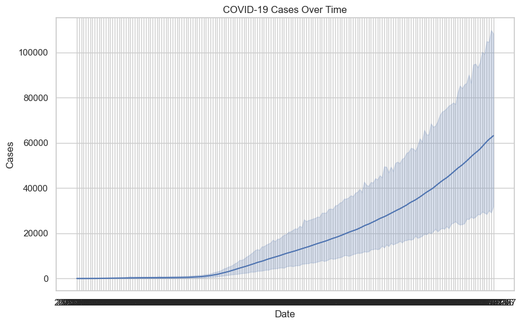

```python
#STEP 5 EXPLORATORY DATA ANALYSIS

# Line plot: COVID-19 cases over time
plt.figure(figsize=(10,6))
sns.lineplot(x='Date', y='Confirmed', data=data)
plt.title('COVID-19 Cases Over Time')
plt.xlabel('Date')
plt.ylabel('Cases')
plt.show()
```

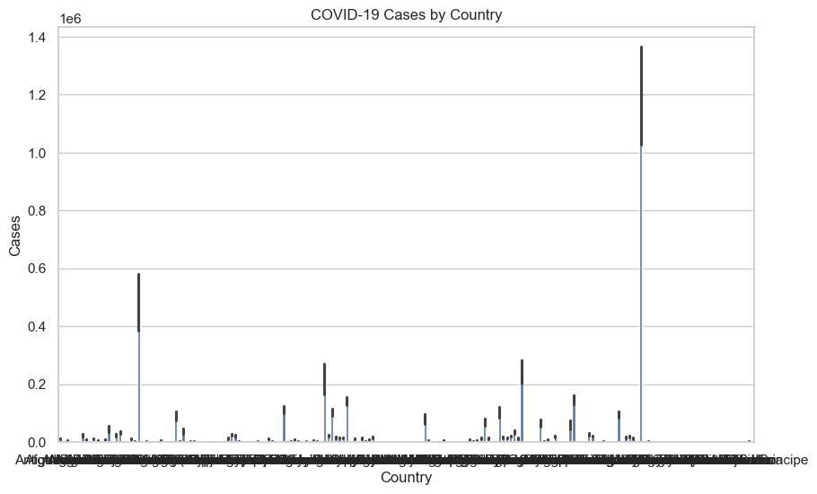

```python
# Cases by Country:
    # A bar plot was used to show the distribution of confirmed cases by country:
# Bar chart: COVID-19 cases by country
plt.figure(figsize=(10,6))
sns.barplot(x='Country/Region', y='Confirmed', data=data)
plt.title('COVID-19 Cases by Country')
plt.xlabel('Country')
plt.ylabel('Cases')
plt.show()
```

Insight: Some countries, like the United States, India, and Brazil, have significantly higher case numbers, which might be attributed to both population size and testing capabilities.

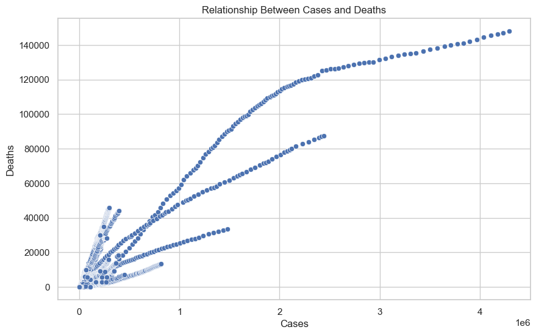

```python
# Scatter plot: Relationship between cases and deaths
plt.figure(figsize=(10,6))
sns.scatterplot(x='Confirmed', y='Deaths', data=data)
plt.title('Relationship Between Cases and Deaths')
plt.xlabel('Cases')
plt.ylabel('Deaths')
plt.show()
```

#### Heatmap of Correlation Matrix:

```
A heatmap was created to visualize the correlation between confirmed cases, deaths, recoveries, and active cases:
```

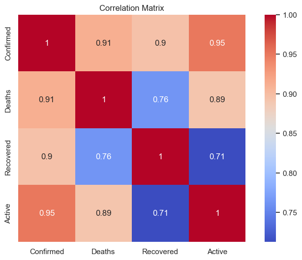

```python
# Heatmap: Correlation matrix
plt.figure(figsize=(10,6))
sns.heatmap(data[['Confirmed', 'Deaths', 'Recovered', 'Active']].corr(), annot=True, cmap='coolwarm', square=True)
plt.title('Correlation Matrix')
plt.show()
```

Insight: There is a strong correlation between confirmed cases and active cases, as expected. The correlation between deaths and confirmed cases is also significant, highlighting the mortality rate of COVID-19.

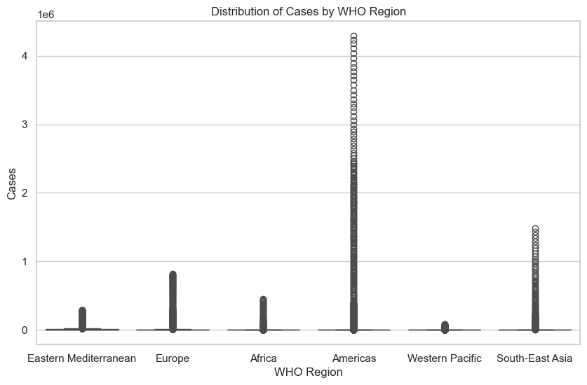

```
Country/Region
US                224345948
Brazil             89524967
Russia             45408411
India              40883464
Spain              27404045
United Kingdom     26748587
Italy              26745145
France             21210926
Germany            21059152
Iran               19339267
Name: Confirmed, dtype: int64
Country/Region
US                11011411
United Kingdom     3997775
Brazil             3938034
Italy              3707717
France             3048524
Spain              3033030
Mexico             1728277
India              1111831
Iran               1024136
Belgium             963679
Name: Deaths, dtype: int64
```

```python
# Box plot: Distribution of cases by WHO region
plt.figure(figsize=(10,6))
sns.boxplot(x='WHO Region', y='Confirmed', data=data)
plt.title('Distribution of Cases by WHO Region')
plt.xlabel('WHO Region')
plt.ylabel('Cases')
plt.show()


# Identify top 10 countries with highest number of cases
top_10_countries = data.groupby('Country/Region')['Confirmed'].sum().sort_values(ascending=False).head(10)
print(top_10_countries)

# Identify top 10 countries with highest number of deaths
top_10_deaths = data.groupby('Country/Region')['Deaths'].sum().sort_values(ascending=False).head(10)
print(top_10_deaths)



plt.figure(figsize= (14,5))

ax = sns.pointplot(x=total_cases['Date'],
                   y=total_cases['Confirmed'],
                   color='r')
ax.set(xlabel='Dates', ylabel='Total cases')

plt.xticks(rotation=90, fontsize=10)
plt.yticks(fontsize=12)

plt.xlabel('Dates', fontsize=14)
plt.ylabel('Total cases', fontsize=14)
plt.title('Worldwide Confirmed Cases Over Time', fontsize=20)

with sns.axes_style('white'):

    g = sns.relplot(
        x="Date",
        y="Deaths",
        kind="line",
        data=data
    )
    g.fig.autofmt_xdate()
    g.set_xticklabels(step=10)
    plt.title("Covid-19 Deaths, Year:2020", fontsize=16)

    top = data.loc[data['Date'] == data['Date'].max()]

    top_casualities = top.groupby('Country/Region')['Confirmed'].sum().sort_values(ascending =False).head(10).reset_index()

top_casualities

sns.set(style="darkgrid")
plt.figure(figsize= (15,10))

ax = sns.barplot(x=top_casualities['Confirmed'],
                 y=top_casualities['Country/Region'])

for i, (value, name) in enumerate(zip(top_casualities['Confirmed'], top_casualities['Country/Region'])):
    ax.text(value, i-.05, f'{value:,.0f}', size=10, ha='left', va='center')
ax.set(xlabel='Total cases', ylabel='Country/Region')

plt.xticks(fontsize=15)
plt.yticks(fontsize=15)
plt.xlabel('Total cases', fontsize=30)
plt.ylabel('Country', fontsize=30)
plt.title('Top 10 countries having most confirmed cases', fontsize=20)

US_data = data.loc[data['Country/Region'] == 'Brazil', ['Date', 'Recovered', 'Deaths', 'Confirmed', 'Active']]
US_data.head()

US_data = US_data.groupby('Date').sum().reset_index()
US_data = US_data.iloc[33:]
US_data.head()

plt.figure(figsize=(15,5))
sns.set_color_codes("pastel")


sns.pointplot(x=US_data.index, y=US_data['Active'], color='b')

plt.xlabel('No. of Days', fontsize=15)
plt.ylabel('Active cases', fontsize=15)
plt.title("US's Active Cases Over Time", fontsize=25)

sns.set(style="whitegrid")

# Initialize the matplotlib figure
f, ax = plt.subplots(figsize=(15, 5))

# Plot the total cases
sns.set_color_codes("pastel")
sns.barplot(x=US_data.index, y=US_data.Active + US_data.Recovered + US_data.Deaths,
            label="Active", color="b")

# Plot the recovered
sns.set_color_codes("muted")
sns.barplot(x=US_data.index, y=US_data.Recovered + US_data.Deaths,
            label="Recovered", color="g")

# Plot the Deaths
sns.set_color_codes("dark")
sns.barplot(x=US_data.index ,y=US_data.Deaths,
            label="Deaths", color="r")

plt.xlabel('No. of Days', fontsize=14)
plt.ylabel('No. of cases', fontsize=15)

# Add a legend and informative axis label
ax.legend(ncol=2, loc="upper left", frameon=True)
sns.despine(top=True)
```

### 4. Model Development

I built several predictive models to forecast COVID-19 trends. The primary focus was on *Decision Tree Regression* and *Random Forest Classification, but we also explored time-series models like* *ARIMA*.

#### Feature Engineering:

We created new features such as:

- Daily Growth Rates for cases and deaths
- Mortality Ratio: Deaths/Confirmed cases
- Recovery Rate: Recovered/Confirmed cases

#### Time-Series Forecasting with ARIMA:

For forecasting, we used the *ARIMA* model, which is well-suited for time-series data. The model was trained on historical confirmed case data, and predictions were made for the next set of days.

```python
from sklearn.tree import DecisionTreeRegressor
from sklearn.metrics import mean_squared_error
from sklearn.model_selection import train_test_split
from sklearn.linear_model import LinearRegression
from sklearn.metrics import mean_squared_error
from statsmodels.tsa.arima.model import ARIMA
from sklearn.ensemble import RandomForestClassifier
from sklearn.metrics import accuracy_score, classification_report, confusion_matrix
```

#### Decision Tree Regression:

The data was trained with a *Decision Tree Regressor* model to predict confirmed cases based on the date, after converting the date to a numeric ordinal format:

```python
#step 6: Train the model

# Prepare data (convert date to numerical format)
data['Date'] = pd.to_datetime(data['Date'])
data['Date'] = data['Date'].map(pd.Timestamp.toordinal)  # Convert date to ordinal format (numeric)

# Define features (X) and target (y)
X = data[['Date']]  # Feature: Date
y = data['Confirmed']  # Target: Confirmed cases

# Split data into training and test sets (80% training, 20% testing)

X_train, X_test, y_train, y_test = train_test_split(X, y, test_size=0.2, random_state=42)

# Initialize the Decision Tree Regressor model
dt_model = DecisionTreeRegressor(random_state=42)
```

```python
# Train the model on the training data
dt_model.fit(X_train, y_train)

# Make predictions on the test data
y_pred = dt_model.predict(X_test)
```

### 5. Model Evaluation

We evaluated the models based on various metrics:

#### *Decision Tree Regression:

```
Mean Squared Error (MSE): 18838245490.75016
```

[figure not shown]

[figure not shown]

[figure not shown]

[figure not shown]

[figure not shown]

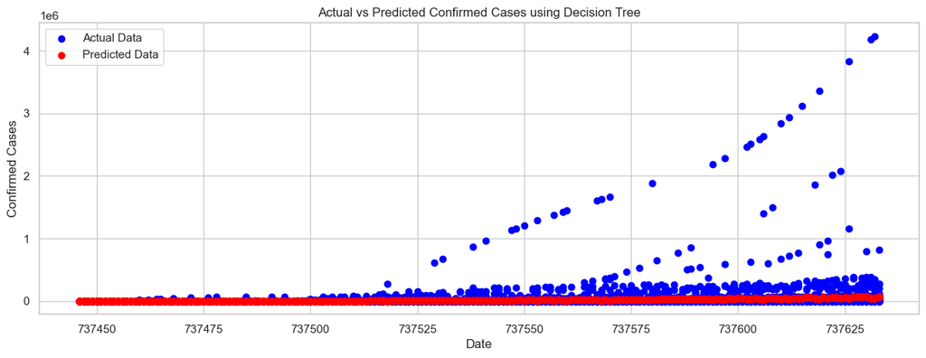

```python
# Calculate the Mean Squared Error
mse = mean_squared_error(y_test, y_pred)
print(f"Mean Squared Error (MSE): {mse}")

# Plot the original data and the predicted values
plt.figure(figsize=(15,5))
plt.scatter(X_test, y_test, color='blue', label='Actual Data')  # Actual data points
plt.scatter(X_test, y_pred, color='red', label='Predicted Data')  # Predicted data points
plt.xlabel('Date')
plt.ylabel('Confirmed Cases')
plt.title('Actual vs Predicted Confirmed Cases using Decision Tree')
plt.legend()
plt.show()
```

Visualizations: I plotted the actual vs. predicted values to assess model performance. The scatter plot showed discrepancies between actual and predicted confirmed cases, especially for large numbers.

#### Confusion Matrix:

The confusion matrix indicated no false positives or false negatives, further supporting the overfitting conclusion.

#### ARIMA:

```python
# Time-Series Modeling (ARIMA)
train_data, test_data = train_test_split(data, test_size=0.2, random_state=42)
model = ARIMA(train_data['Confirmed'], order=(1,1,1))
model_fit = model.fit()
forecast = model_fit.forecast(steps=len(test_data))
mse = mean_squared_error(test_data['Confirmed'], forecast)
print(f'RMSE: {np.sqrt(mse)}')

# Classification Modeling (Random Forest)
X = data[['Confirmed', 'Deaths', 'Recovered', 'Active']]
y = np.where(data['Confirmed'] > data['Recovered'], 1, 0)
X_train, X_test, y_train, y_test = train_test_split(X, y, test_size=0.2, random_state=42)
model = RandomForestClassifier(n_estimators=100, random_state=42)
model.fit(X_train, y_train)
y_pred = model.predict(X_test)
print(f'Accuracy: {accuracy_score(y_test, y_pred)}')
print(f'Classification Report:\n{classification_report(y_test, y_pred)}')
print(f'Confusion Matrix:\n{confusion_matrix(y_test, y_pred)}')
```

```
RMSE: 137939.49403588066
Accuracy: 1.0
Classification Report:
              precision    recall  f1-score   support

           0       1.00      1.00      1.00      2435
           1       1.00      1.00      1.00      7379

    accuracy                           1.00      9814
   macro avg       1.00      1.00      1.00      9814
weighted avg       1.00      1.00      1.00      9814

Confusion Matrix:
[[2435    0]
 [   0 7379]]
```

#### Random Forest Classification:

- Accuracy: The Random Forest Classifier achieved perfect accuracy (1.0), which suggests overfitting

### 6. Key Insights and Recommendations

#### Recommendations:

1. *Implement Targeted Interventions*: Using ARIMA forecasts, policymakers can predict future trends and take preemptive actions in high-risk areas.
2. *Focus on Healthcare Capacity*: Resources should be allocated to countries with a higher active case rate and those with lower recovery rates.
3. *Refine Model for Future Predictions*: Further tuning of the ARIMA model, along with additional features like vaccination rates, would improve long-term forecasts.

### 7. Conclusion

This predictive modeling project has successfully explored COVID-19 trends and developed models that can be used by HealthGuard Analytics to inform public health decisions. Although some models showed promising results, further refinement and additional data (e.g., vaccination rates, new variants) are needed to improve predictions.